# Data Munging: GRLS and Tick-Borne Disease

Grace Faulkner

2023-12-11

## Golden Retriever Lifetime Study

The **Golden Retriever Lifetime Study (GRLS)** from the Morris Animal Foundation is a prospective, observational cohort study focused on identifying risk factors for canine cancer and other canine diseases. This unique cohort is comprised of over 3,000 golden retrievers from across the US that are followed throughout their lifetime in attempts to identify genetic, dietary and environmental exposures. The dogs in this cohort were enrolled within their first 2 years of age and every year, their owners and veterinarians have submitted surveys about their lifestyle and health. Using the Morris Animal Foundation GRLS data commons, I have accessed these data with an interest in **canine tick-borne disease (TBD)**.

## Cohort Summary

The GRLS survey data are stored in the Morris Animal Foundation data repository known as the data commons. The data commons contains information on dog demographics, activity and lifestyle, behavior, medication, and conditions such as infectious disease, gastrointestinal, and ear, nose and throat. From the data commons, I downloaded and explored relevant datasets that could describe TBD diagnoses and TBD-preventative medications.

After exploring the data commons, I downloaded the dog demographics dataset to determine the size and characteristics of the cohort. This dataset had information on birth date, enrollment date, and reproductive status. Since there was no variable related to cohort status or end date, I have assumed all dogs listed in this dataset to be active.

This cohort is comprised of 3,044 dogs, with 50.5% being male. More of the dogs were fixed (spayed or neutered) than intact. The average (mean) age of the cohort is 10.5 years. The average (mean) time contributed to the study is 9.2 years. The earliest enrollment date is September 2012 and the last enrollment date is July 2015. I calculated the age and year in study by splitting the birth_date and enrollment_date into month and year and subtracting from the current year (2023).

```
## [1] 3044
```

```
## dog_prof
##
##  4  Variables      3044  Observations
## --------------------------------------------------------------------------------
## subject_id
##        n  missing distinct
##     3044        0     3044
##
## lowest : grls007MPNZZ grls00NB23WW grls01C2L8RR grls01LNL888 grls01RDAKNN
## highest: grlsZW6L5W33 grlsZY1Z1OSS grlsZY5KYKXX grlsZYI0K6LL grlsZYWPKKJJ
## --------------------------------------------------------------------------------
## sex_status
##        n  missing distinct
##     3044        0        4
##
## Value      Intact Female   Intact Male Neutered Male Spayed Female
## Frequency            219           431          1109          1285
## Proportion         0.072         0.142         0.364         0.422
## --------------------------------------------------------------------------------
## birth_date
##        n  missing distinct
##     3044        0       56
##
## lowest : 2010-02 2010-03 2010-04 2010-05 2010-06
## highest: 2014-05 2014-06 2014-07 2014-08 2014-09
## --------------------------------------------------------------------------------
## enrolled_date
##        n  missing distinct
##     3044        0       34
##
## lowest : 2012-09 2012-10 2012-11 2012-12 2013-01
## highest: 2015-02 2015-03 2015-04 2015-06 2015-07
## --------------------------------------------------------------------------------
```

| ReproductiveStatus | Freq |
| --- | --- |
| Intact Female | 219 |
| Intact Male | 431 |
| Neutered Male | 1109 |
| Spayed Female | 1285 |

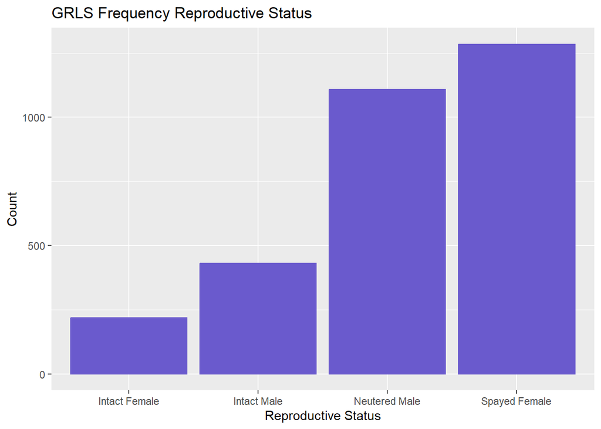

```
##    Min. 1st Qu.  Median    Mean 3rd Qu.    Max.
##    9.00   10.00   10.00   10.51   11.00   13.00
```

|  | age 9 | age 10 | age 11 | age 12 | age 13 |
| --- | --- | --- | --- | --- | --- |
| sex_status |  |  |  |  |  |
| Intact Female | 40 | 94 | 58 | 25 | 2 |
| Intact Male | 74 | 162 | 117 | 70 | 8 |
| Neutered Male | 175 | 385 | 364 | 157 | 28 |
| Spayed Female | 193 | 472 | 390 | 211 | 19 |
| #Total cases | 482 | 1113 | 929 | 463 | 57 |

```
##    Min. 1st Qu.  Median    Mean 3rd Qu.    Max.
##   8.000   9.000   9.000   9.211  10.000  11.000
```

## Infectious Disease

From the Data Commons, I accessed the Conditions_Infectious Disease dataset to see which conditions were reported by veterinarians each year.

First, I explored the column headers to see which, if any, TBD, were reported. Additionally, I looked to see how the conditions were reported by noting the columns “record_date”, “to_date” and “any”.

This dataset is organized by each dog through every survey year up to year 7. Also, depending on the ‘to date’ variable, the condition could have been diagnosed only in that survey year or at any time during their participation in the cohort (0 - Reported conditions diagnosed only in that study year, 1 - All reported conditions diagnosed from baseline through that study year). In order to describe unique TBD diagnoses, I filtered based on if the condition was diagnosed and only diagnosed in that year the survey was submitted (‘to date’ variable) and cross-referenced with the ‘any’ variable to make sure an infectious condition was reported that year (0 - No conditions diagnosed, 1 - At least one condition diagnosed).

My search strategy was to filter records based on the ‘to date’ and ‘any’ variable to select records could have had a reported TBD. In this dataset, every dog in the cohort is represented or had at least 1 reported condition in at least one annual survey.

```r
##Import GRLS Data file
GRLS <- read.csv('GRLS_conditions_infectious.csv', header=TRUE, stringsAsFactors=FALSE)

##how many unique subject ids (or dogs) are in this csv file
length(unique(GRLS$subject_id))
```

```
## [1] 3044
```

```r
##Column names of csv file to determine columns of interest as related to tick-borne disease
names(GRLS)
```

```
##  [1] "subject_id"
##  [2] "relationship_category"
##  [3] "year_in_study"
##  [4] "record_date"
##  [5] "to_date"
##  [6] "any"
##  [7] "anaplasma"
##  [8] "babesia"
##  [9] "canine_herpesvirus"
## [10] "coccidia"
## [11] "cryptosporidium"
## [12] "ear_mites"
## [13] "ehrlichia"
## [14] "eimeria"
## [15] "fleas"
```

[output cut: 20 more lines]

```r
##determine what the first few lines of csv file look like
head(GRLS, n=10)
```

```
##      subject_id relationship_category year_in_study
## 1  grls007MPNZZ                   DOG             0
## 2  grls007MPNZZ                   DOG             0
## 3  grls007MPNZZ                   DOG             1
## 4  grls007MPNZZ                   DOG             1
## 5  grls007MPNZZ                   DOG             2
## 6  grls007MPNZZ                   DOG             2
## 7  grls007MPNZZ                   DOG             3
## 8  grls007MPNZZ                   DOG             3
## 9  grls007MPNZZ                   DOG             4
## 10 grls007MPNZZ                   DOG             4
##                        record_date to_date any anaplasma babesia
## 1  2014-06,2014-08,2015-01,2015-03       0   0         0       0
## 2                                        1   0         0       0
## 3          2015-05,2015-08,2015-09       0   0         0       0
```

[output cut: 73 more lines]

```r
##determine summary statistics for each columns
describe(GRLS)
```

```
## GRLS
##
##  35  Variables      48704  Observations
## --------------------------------------------------------------------------------
## subject_id
##        n  missing distinct
##    48704        0     3044
##
## lowest : grls007MPNZZ grls00NB23WW grls01C2L8RR grls01LNL888 grls01RDAKNN
## highest: grlsZW6L5W33 grlsZY1Z1OSS grlsZY5KYKXX grlsZYI0K6LL grlsZYWPKKJJ
## --------------------------------------------------------------------------------
## relationship_category
##        n  missing distinct    value
##    48704        0        1      DOG
##
## Value        DOG
## Frequency  48704
## Proportion     1
## --------------------------------------------------------------------------------
## year_in_study
##        n  missing distinct     Info     Mean      Gmd
##    48704        0        8    0.984      3.5    2.625
##
## Value          0     1     2     3     4     5     6     7
## Frequency   6088  6088  6088  6088  6088  6088  6088  6088
## Proportion 0.125 0.125 0.125 0.125 0.125 0.125 0.125 0.125
##
## For the frequency table, variable is rounded to the nearest 0
## --------------------------------------------------------------------------------
## record_date
##        n  missing distinct
##    18963    29741     1456
##
## lowest : 2012-09         2012-10         2012-11         2012-11,2014-10 2012-12
## highest: 2022-11         2022-12         2023-01         2023-02         2023-04
## --------------------------------------------------------------------------------
## to_date
##        n  missing distinct     Info      Sum     Mean      Gmd
##    48704        0        2     0.75    24352      0.5      0.5
##
```

[output cut: 153 more lines]

```
##    43315     5389        2    0.018      267 0.006164  0.01225
##
## --------------------------------------------------------------------------------
## other
##        n  missing distinct     Info     Mean      Gmd
##    43315     5389        1        0        0        0
##
## Value          0
## Frequency  43315
## Proportion     1
## --------------------------------------------------------------------------------
##
## Variables with all observations missing:
##
## [1] other_specify
```

## Tick-Borne Disease

After I explored the data contents and structure, I selected for TBD conditions. Like humans, dogs can get TBD from tick bites that are infected with pathogens. From the infectious diseases reported, I will use the following diagnoses related to TBD: **Anaplasmosis**, **Babesiosis**, **Ehrlichiosis**, **Lyme Disease** and **Rocky Mountain Spotted Fever (RMSF)**.

I created a new dataframe selecting the columns subject_id, year_in_study, record_date, to_date, any, and the TBD conditions (Anaplasmosis, Babesiosis, Ehrlichiosis, Lyme Disease and Rocky Mountain Spotted Fever). The conditions are coded as 0 and 1, indicating disease not reported and disease reported. I summed each TBD column to determine case counts and created a table and graph. This dataset had 48,704 records. Of the TBD reported, **Lyme Disease** had the most reported cases. There were no records of Babesiosis, which could be due to its absence on annual screening tests of TBD. In dogs, the SNAP test will test for Heartworm, Lyme Disease, Anaplasmosis, Ehrlichiosis, and RMSF.

```
##     subject_id year_in_study             record_date to_date any anaplasma
## 1 grls02RRJK88             3                 2016-08       0   1         0
## 2 grls02VDCV99             0                 2013-02       0   1         0
## 3 grls03MTKHLL             0 2014-04,2015-01,2015-03       0   1         0
## 4 grls04DN2S55             0                 2014-12       0   1         0
## 5 grls06YF0BSS             0                 2013-05       0   1         0
##   babesia ehrlichia lyme_disease rocky_mountain_spotted_fever ticks
## 1       0         0            0                            0     0
## 2       0         0            0                            0     0
## 3       0         0            0                            0     0
## 4       0         0            0                            0     0
## 5       0         0            0                            0     0
```

```
## [1] 111
```

```
## [1] 0
```

```
## [1] 37
```

```
## [1] 216
```

```
## [1] 15
```

| TickBorneDisease | Diagnoses |
| --- | --- |
| Anaplasmosis | 111 |
| Babesia | 0 |
| Ehrlichia | 37 |
| Lyme Disease | 216 |
| RMSF | 15 |

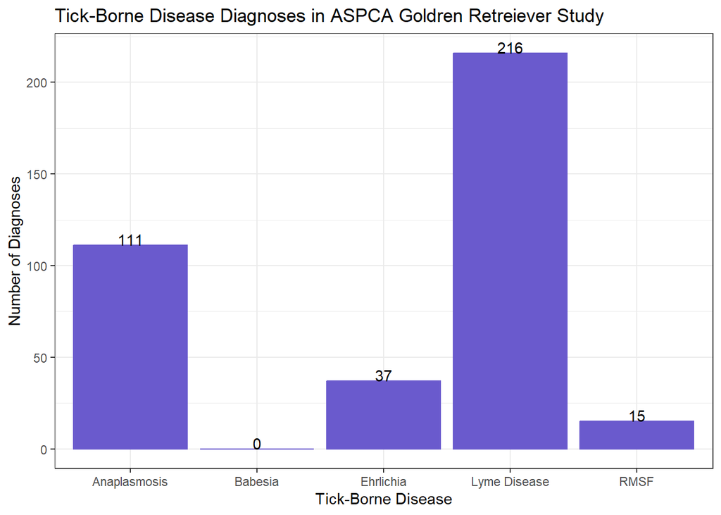

## Repeat Positive TBD reports

After determining the total number of TBD cases in this cohort, I wanted to see if dogs were only reporting one positive TBD condition once or if they were experiencing repeat positive TBD conditions throughout their time in the study. Dogs can get bit by ticks multiple times and become re-infected. I grouped each TBD by subject_id to see how often TBD was being reported per dog.

### Lyme Disease

In this cohort, 144 different dogs had reported Lyme Disease. Most of these dogs only reported Lyme Disease once, with an observed decreasing trend (min=1, max=5).

```
## [1] 144
```

```
## agg_Lyme
##
##  2  Variables      144  Observations
## --------------------------------------------------------------------------------
## subject_id
##        n  missing distinct
##      144        0      144
##
## lowest : grls0TAMSHFF grls1XY17PSS grls2ME5U9UU grls33E7KL55 grls3HMHXDKK
## highest: grlsZ515TIPP grlsZIRB97LL grlsZKDZ9N00 grlsZO8JN6BB grlsZSMLMUPP
## --------------------------------------------------------------------------------
## total_count
##        n  missing distinct     Info     Mean      Gmd
##      144        0        5    0.692      1.5   0.7545
##
## Value          1     2     3     4     5
## Frequency     96    32    10     4     2
## Proportion 0.667 0.222 0.069 0.028 0.014
##
## For the frequency table, variable is rounded to the nearest 0
## --------------------------------------------------------------------------------
```

### Anaplasmosis

In this cohort, 81 different dogs had reported Anaplasmosis. Most of these dogs only reported Anaplasmosis once, with an observed decreasing trend (min=1, max=3).

```
## [1] 81
```

```
## agg_Ana
##
##  2  Variables      81  Observations
## --------------------------------------------------------------------------------
## subject_id
##        n  missing distinct
##       81        0       81
##
## lowest : grls0762M2FF grls0CSZ8WSS grls0TAMSHFF grls1XTARN88 grls3HMHXDKK
## highest: grlsXISA2YRR grlsXWVNQZHH grlsY9QUTVKK grlsZJOFZENN grlsZTK09ORR
## --------------------------------------------------------------------------------
## total_count
##        n  missing distinct     Info     Mean      Gmd
##       81        0        3    0.667     1.37   0.5364
##
## Value          1     2     3
## Frequency     55    22     4
## Proportion 0.679 0.272 0.049
##
## For the frequency table, variable is rounded to the nearest 0
## --------------------------------------------------------------------------------
```

### Ehrlichia

In this cohort, 27 different dogs had reported Ehrlichiosis. Most of these dogs only reported Ehrlichiosis once, with an observed decreasing trend (min=1, max=4).

```
## [1] 27
```

```
## agg_Ehr
##
##  2  Variables      27  Observations
## --------------------------------------------------------------------------------
## subject_id
##        n  missing distinct
##       27        0       27
##
## lowest : grls1G2OMPTT grls1XTARN88 grls2JIWZ3TT grls3L76FSS  grls4XF9HJ66
## highest: grlsU02GKYQQ grlsUJLQ5OSS grlsW9VLDHDD grlsX2F2CUTT grlsZPQC2000
## --------------------------------------------------------------------------------
## total_count
##        n  missing distinct     Info     Mean      Gmd
##       27        0        4    0.588     1.37   0.6154
##
## Value          1     2     3     4
## Frequency     20     5     1     1
## Proportion 0.741 0.185 0.037 0.037
##
## For the frequency table, variable is rounded to the nearest 0
## --------------------------------------------------------------------------------
```

### Rocky Mountain Spotted Fever

In this cohort, 13 different dogs had reported Rock Mountain Spotted Fever. Most of these dogs only reported RMSF once except for 1 that reported RMSF 3 times.

```
## [1] 13
```

```
## agg_RMSF
##
##  2  Variables      13  Observations
## --------------------------------------------------------------------------------
## subject_id
##        n  missing distinct
##       13        0       13
##
## grls45HWKQYY (1, 0.077), grls9NWXF322 (1, 0.077), grlsEZ8CTFQQ (1, 0.077),
## grlsIRH5Z6OO (1, 0.077), grlsJLU8ABKK (1, 0.077), grlsJT6W5YY (1, 0.077),
## grlsO3BDIVWW (1, 0.077), grlsQIDG6VLL (1, 0.077), grlsTGEU6344 (1, 0.077),
## grlsUD2OGC44 (1, 0.077), grlsVSCFCFSS (1, 0.077), grlsWLNH5544 (1, 0.077),
## grlsWPC63PJJ (1, 0.077)
## --------------------------------------------------------------------------------
## total_count
##        n  missing distinct     Info     Mean      Gmd
##       13        0        2    0.214    1.154   0.3077
##
## Value          1     3
## Frequency     12     1
## Proportion 0.923 0.077
## --------------------------------------------------------------------------------
```

## Year in Study and TBD

Dogs can get bit by ticks throughout their lifetime, presenting an opportunity for re-infection. I wanted to describe the relationship between age and TBD diagnosis to see when TBD was being reported in this cohort. I created a table and chart of each reported TBD counts by each year in the study. Due to the different enrollment years (2012-2015), this does not reflect annual or yearly totals of disease incidence.

**Lyme Disease** was most reported during the **first 3 years (max=year 1** of being in the study. This was most likely reported puppyhood to age 4. After Year 2 in the study, there are decreasing counts of reported Lyme Disease.

**Anaplasmosis** was most reported during **year 3** with more cases being reported from year 1 to 5. This was most likely reported after puppyhood (from age 2 to 6).

**Ehrlichiosis** was most reported during **year 4** with more cases being reported from year 3 to 5. This was most likely reported after puppyhood (from age 3 to 6).

**Rocky Mountain Spotted Fever** was most reported during **year 2** but had overall low case counts in all study years.

Disclaimer: Data is available through study year 7 due to embargo period

| Year_in_Study | LymeDisease |
| --- | --- |
| 0 | 45 |
| 1 | 54 |
| 2 | 39 |
| 3 | 32 |
| 4 | 18 |
| 5 | 13 |
| 6 | 13 |
| 7 | 2 |

| Year_in_Study | Anaplasmosis |
| --- | --- |
| 0 | 7 |
| 1 | 15 |
| 2 | 22 |
| 3 | 24 |
| 4 | 16 |
| 5 | 18 |
| 6 | 8 |
| 7 | 1 |

| Year_in_Study | Ehrlichia |
| --- | --- |
| 0 | 3 |
| 1 | 1 |
| 2 | 3 |
| 3 | 8 |
| 4 | 11 |
| 5 | 6 |
| 6 | 3 |
| 7 | 2 |

| Year_in_Study | RMSF |
| --- | --- |
| 0 | 2 |
| 2 | 5 |
| 3 | 1 |
| 4 | 3 |
| 5 | 2 |
| 6 | 2 |

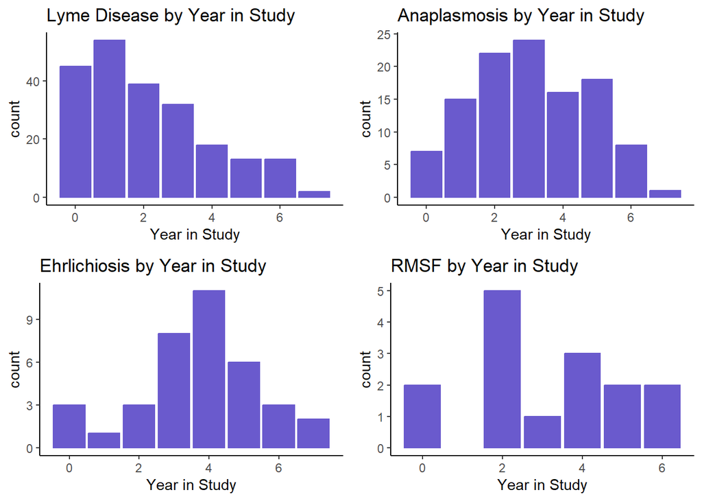

## TBD Coinfections

Ticks can carry **more than 1 disease** and cause multiple infections. I wanted to describe the relationship between reported TBD coinfections to see if dogs were reporting only 1 TBD or more. I created a new column, **Tscore** to indicate coinfections that summed each row of TBD. Most of the records in this dataset had no reported TBD. Of the records with a reported TBD, most only had 1 reported TBD with a decreasing trend from 1 to 3 TBD infections.

| TBD_Diagnosed | Freq |
| --- | --- |
| No | 1275 |
| Yes | 347 |

| NumberofInfections | Freq |
| --- | --- |
| 0 | 1275 |
| 1 | 316 |
| 2 | 30 |
| 3 | 1 |

## TBD and Ticks

```
## [1] 51
```

| Tick_Borne_Disease | Tick_Observed |
| --- | --- |
| Lyme Disease | 0 |
| Anaplasmosis | 2 |
| Ehrlichia | 0 |
| RMSF | 1 |

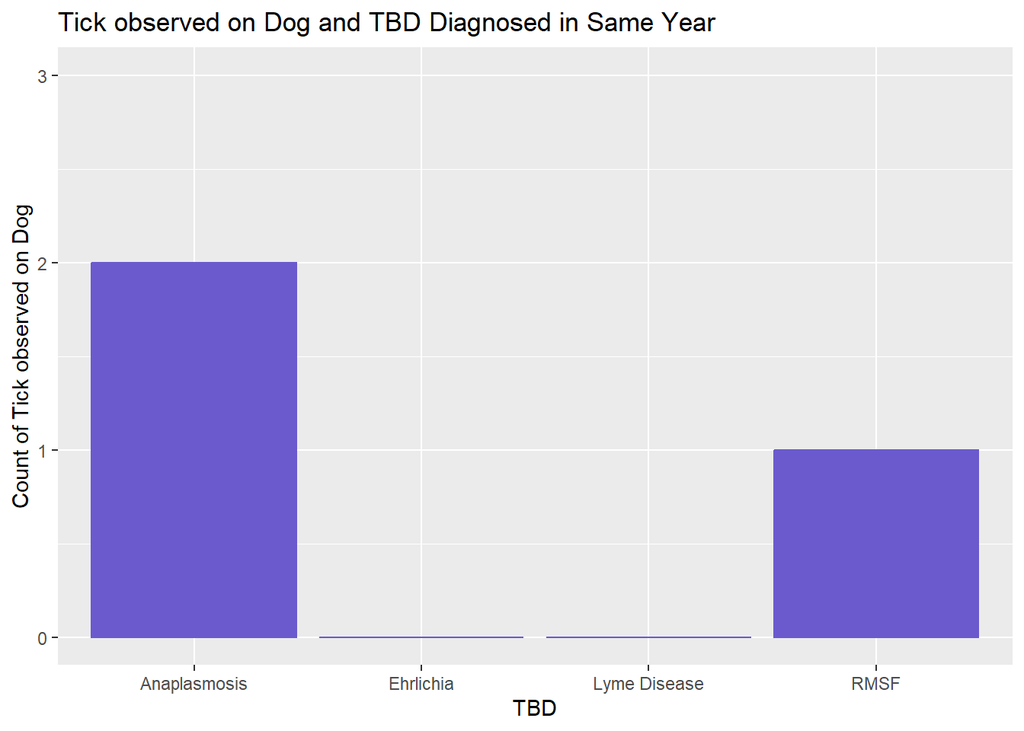

## Medications

TBD can be prevented through routine topical and oral administration of tick prevention. I wanted to describe the use of tick-prevention in this cohort and the relationship between prevention and TBD. I downloaded the medications dataset, which had 40,401 records with **751 different medication ingredients** recorded. This dataset also has information on administration method, dose, and frequency.

First, I created a frequency table and reviewed the top 10 medication ingredients. Then, I did a google search for common active ingredients in tick-prevention in order to filter appropriate records. Tick prevention can contain ingredients such as Afoxolaner,Fluralaner, Fipronil, (S)-Methoprene, Imidacloprid, Permethrin, Pyriproxyfen, Dinotefuran, and Pyriproxyfen and are typically administered in an **oral** or **topical** form. I selected records to create a new data frame (prev) that contained all records with tick-prevention related ingredients.

Disclaimer: Like the infectious disease date, this data is available through study year 7 due to embargo period

```
##     subject_id year_in_study record_date dose      dose_unit
## 1 grls007MPNZZ             0     2014-06    1 Other, specify
## 2 grls007MPNZZ             0     2014-06    1 Other, specify
## 3 grls007MPNZZ             0     2014-06  3-5          Drops
## 4 grls007MPNZZ             0     2014-08    1          Units
## 5 grls007MPNZZ             0     2014-08    1 Other, specify
##              dose_unit_specify   duration  duration_unit         frequency
## 1 based on weight (50-100 lbs) Continuous Not applicable Q (Days), specify
## 2                         tube Continuous Not applicable Q (Days), specify
## 3                         <NA>         10           Days               SID
## 4                         <NA>         10           Days               SID
## 5          tablet/pill/capsule Continuous           <NA>     Other specify
##   frequency_specify specify_days specify_hours administration_method
## 1              <NA>           30            NA                  <NA>
## 2              <NA>           30            NA                  <NA>
```

[output cut: 21 more lines]

Data summary

| Name | med |
| --- | --- |
| Number of rows | 40401 |
| Number of columns | 17 |
| _______________________ |  |
| Column type frequency: |  |
| character | 13 |
| numeric | 4 |
| ________________________ |  |
| Group variables | None |

**Variable type: character**

| skim_variable | n_missing | complete_rate | min | max | empty | n_unique | whitespace |
| --- | --- | --- | --- | --- | --- | --- | --- |
| subject_id | 0 | 1.00 | 9 | 12 | 0 | 2877 | 0 |
| record_date | 0 | 1.00 | 7 | 7 | 0 | 125 | 0 |
| dose | 357 | 0.99 | 1 | 171 | 0 | 4659 | 0 |
| dose_unit | 79 | 1.00 | 2 | 14 | 0 | 22 | 0 |
| dose_unit_specify | 31222 | 0.23 | 1 | 65 | 0 | 178 | 0 |
| duration | 1444 | 0.96 | 1 | 10 | 0 | 13 | 0 |
| duration_unit | 20535 | 0.49 | 4 | 14 | 0 | 4 | 0 |
| frequency | 17 | 1.00 | 3 | 18 | 0 | 14 | 0 |
| frequency_specify | 31169 | 0.23 | 1 | 79 | 0 | 179 | 0 |
| administration_method | 14667 | 0.64 | 4 | 23 | 0 | 7 | 0 |
| administration_method_specify | 39637 | 0.02 | 4 | 25 | 0 | 14 | 0 |
| status | 38525 | 0.05 | 7 | 8 | 0 | 2 | 0 |
| medication_ingredients | 76 | 1.00 | 1 | 143 | 0 | 750 | 0 |

**Variable type: numeric**

| skim_variable | n_missing | complete_rate | mean | sd | p0 | p25 | p50 | p75 | p100 | hist |
| --- | --- | --- | --- | --- | --- | --- | --- | --- | --- | --- |
| year_in_study | 0 | 1.00 | 2.83 | 2.14 | 0 | 1 | 3 | 5 | 7 | ▇▃▆▃▃ |
| specify_days | 31620 | 0.22 | 31.58 | 13.97 | 1 | 30 | 30 | 30 | 180 | ▇▁▁▁▁ |
| specify_hours | 40197 | 0.01 | 13.25 | 7.80 | 1 | 8 | 12 | 15 | 48 | ▇▇▅▁▁ |
| any_medications | 0 | 1.00 | 1.00 | 0.00 | 1 | 1 | 1 | 1 | 1 | ▁▁▇▁▁ |

```
## [1] NA
```

```
## [1] 751
```

| MedicationIngredients | Freq |
| --- | --- |
| Ivermectin, Pyrantel Pamoate | 4078 |
| Afoxolaner | 1721 |
| Lufenuron, Milbemycin Oxime | 1602 |
| Carprofen | 1593 |
| Metronidazole | 1323 |
| Ivermectin | 1240 |
| Milbemycin Oxime | 1049 |
| Oclacitinib | 968 |
| Fluralaner | 948 |
| Cefpodoxime Proxetil | 924 |

```
##      subject_id year_in_study record_date            dose      dose_unit
## 1  grls007MPNZZ             0     2014-06               1 Other, specify
## 2  grls007MPNZZ             1     2015-05          1 dose          Units
## 3  grls007MPNZZ             2     2016-06               1          Units
## 4  grls007MPNZZ             4     2018-05 60-120pound dog          Units
## 5  grls01C2L8RR             3     2017-08          60-121 Other, specify
## 6  grls020IW1ZZ             1     2016-02       88-123 lb Other, specify
## 7  grls020IW1ZZ             1     2016-02       89-132 lb Other, specify
## 8  grls020IW1ZZ             2     2017-02            1400             Mg
## 9  grls020IW1ZZ             3     2018-03            1400             Mg
## 10 grls020IW1ZZ             5     2020-02        88-123lb Other, specify
##    dose_unit_specify   duration  duration_unit         frequency
## 1               tube Continuous Not applicable Q (Days), specify
## 2               <NA> Continuous           <NA>          Q (Days)
## 3               <NA> Continuous           <NA>          Q (Days)
```

[output cut: 40 more lines]

```
## [1] 1711
```

| MedicationIngredients | Freq |
| --- | --- |
| Afoxolaner | 1721 |
| Fluralaner | 948 |
| Fipronil, (S)-Methoprene | 881 |
| Imidacloprid, Permethrin, Pyriproxyfen | 375 |
| Dinotefuran, Permethrin, Pyriproxyfen | 327 |
| Flumethrin, Imidacloprid | 194 |
| Imidacloprid, Moxidectin | 156 |
| Fipronil, Permethrin, Pyriproxyfen | 132 |
| Fipronil | 66 |
| Fipronil, Pyriproxyfen, (S)-Methoprene | 60 |
| Cyphenothrin, Fipronil | 48 |
| Cyphenothrin, Fipronil, (S)-Methoprene | 31 |
| Fipronil, Permethrin | 8 |
| Permethrin | 7 |
| Afoxolaner, Milbemycin Oxime | 6 |
| Indoxacarb, Permethrin | 6 |
| Permethrin, Pyriproxyfen | 6 |
| Pyriproxyfen | 5 |
| Dinotefuran | 4 |
| Imidacloprid | 4 |

| Var1 | Freq |
| --- | --- |
| No | 35511 |
| Yes | 4814 |

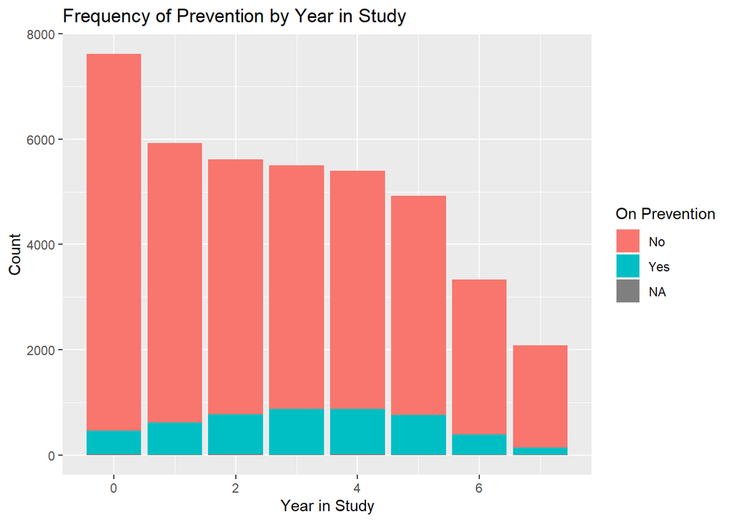

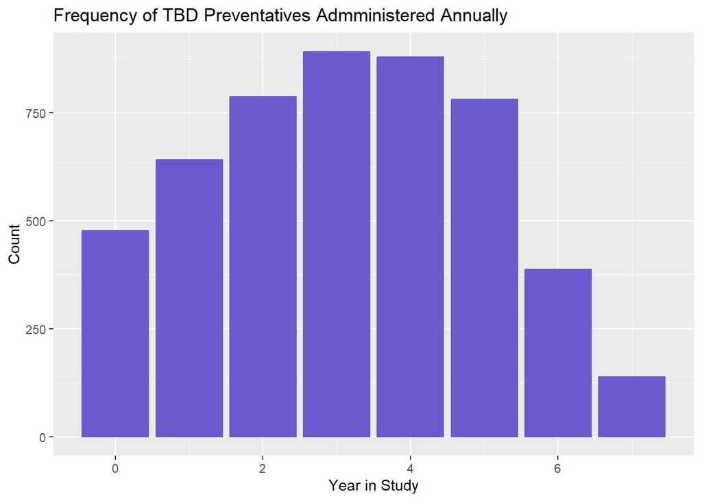

| AdministrationMethod | Freq |
| --- | --- |
| Intramuscular injection | 1 |
| Intravenous injection | 1 |
| Oral | 2467 |
| Other | 1 |
| Other specify | 48 |
| Subcutaneous injection | 1 |
| Topical | 1592 |

```
##        subject_id year_in_study record_date           dose      dose_unit
## 4242 grlsUUTUSYGG             4     2017-11 for her weight            Mcg
## 4243 grlsUUTUSYGG             5     2018-09          44-88 Other, specify
## 4244 grlsUUTUSYGG             6     2019-11   44-88lb dose Other, specify
## 4401 grlsVY18Q2MM             4     2017-11           1000             Mg
## 4402 grlsVY18Q2MM             5     2018-10           1000             Mg
## 4403 grlsVY18Q2MM             6     2019-10           1000             Mg
##      dose_unit_specify   duration duration_unit     frequency frequency_specify
## 4242              <NA>  As needed          <NA>      Q (Days)              <NA>
## 4243   based on weight  As needed          <NA>      Q (Days)              <NA>
## 4244       application Continuous          <NA>      Q (Days)              <NA>
## 4401              <NA> Continuous          <NA>      Q (Days)              <NA>
## 4402              <NA> Continuous          <NA> Other specify      1 to 2 weeks
## 4403              <NA> Continuous          <NA>      Q (Days)              <NA>
##      specify_days specify_hours   administration_method
```

[output cut: 20 more lines]

After filtering for tick-prevention medication ingredients, I merged the prevention medications dataset with the TBD dataset to compare dogs that were on prevention and the administration method, frequency, and TBD. Of all the dogs in the cohort that were on prevention, there were fewer TBD records than the overall total of TBD, indicating that tick prevention has had an impact on disease. Most prevention was administered orally and at monthly intervals, which is common for tick prevention and could indicate good owner-compliance. However, from the 2by2 table on TBD and administration method, there were fewer TBD records for topical administration than oral. Additionally, there were quite a few owners that indicated seasonal administration of tick prevention. However, as ticks have moved into new regions of the US and can be found year-round due to changes in climate, year-round administration is becoming more popular as a recommendation.

| subject_id | year_in_study | record_date.x | dose | dose_unit | dose_unit_specify | duration | duration_unit | frequency | frequency_specify | specify_days | specify_hours | administration_method | administration_method_specify | status | medication_ingredients | any_medications | record_date.y | to_date | any | anaplasma | babesia | ehrlichia | lyme_disease | rocky_mountain_spotted_fever | ticks | TScore | TBD |
| --- | --- | --- | --- | --- | --- | --- | --- | --- | --- | --- | --- | --- | --- | --- | --- | --- | --- | --- | --- | --- | --- | --- | --- | --- | --- | --- | --- |
| grls0762M2FF | 2 | 2016-08 | 21-55 lb application | Other, specify | tube | Continuous | NA | Other specify | monthly | NA | NA | Topical | NA | NA | Imidacloprid, Permethrin, Pyriproxyfen | 1 | 2016-08 | 0 | 1 | 1 | 0 | 0 | 0 | 0 | 0 | 1 | Yes |
| grls0B5181FF | 0 | 2014-05 | 45-88 | Other, specify | based on weight | Continuous | Months | Other, specify | monthly | NA | NA | NA | NA | NA | Fipronil, (S)-Methoprene | 1 | 2014-05 | 0 | 1 | 0 | 0 | 0 | 0 | 0 | 0 | 0 | No |
| grls0B5181FF | 1 | 2015-06 | 45-88 | Other, specify | based on weight | Continuous | NA | Other specify | monthly | NA | NA | NA | NA | NA | Fipronil, (S)-Methoprene | 1 | 2015-06 | 0 | 1 | 0 | 0 | 0 | 0 | 0 | 0 | 0 | No |
| grls0CSZ8WSS | 4 | 2016-12 | 136 | Mg | NA | Continuous | NA | Q (Days) | NA | 30 | NA | Oral | NA | NA | Afoxolaner | 1 | 2016-12 | 0 | 1 | 1 | 0 | 0 | 0 | 0 | 0 | 1 | Yes |
| grls0CSZ8WSS | 5 | 2017-12 | 136 | Mg | NA | Continuous | NA | Q (Days) | NA | 30 | NA | Oral | NA | NA | Afoxolaner | 1 | 2017-12 | 0 | 1 | 1 | 0 | 0 | 0 | 0 | 0 | 1 | Yes |
| grls0CSZ8WSS | 7 | 2019-12 | 136 | Mg | NA | Continuous | NA | Other specify | monthly | NA | NA | Oral | NA | NA | Afoxolaner | 1 | 2019-12 | 0 | 1 | 0 | 0 | 0 | 0 | 0 | 0 | 0 | No |
| grls0F3UPZPP | 3 | 2017-10 | 51-100 | Other, specify | based on weight | Continuous | NA | Other specify | monthly | NA | NA | Oral | NA | NA | Afoxolaner | 1 | 2017-10 | 0 | 1 | 0 | 0 | 0 | 0 | 0 | 0 | 0 | No |
| grls0F3UPZPP | 3 | 2017-10 | 51-100 | Other, specify | based on weight | As needed | NA | Other specify | monthly | NA | NA | Topical | NA | NA | Imidacloprid, Moxidectin | 1 | 2017-10 | 0 | 1 | 0 | 0 | 0 | 0 | 0 | 0 | 0 | No |
| grls0HAV8G99 | 2 | 2016-07 | 2.68 | mL | NA | As needed | NA | Other specify | monthly | NA | NA | Topical | NA | NA | Fipronil, (S)-Methoprene | 1 | 2016-07,2017-01 | 0 | 1 | 0 | 0 | 0 | 0 | 0 | 0 | 0 | No |
| grls0OGJIE22 | 6 | 2020-02 | Large dog | Other, specify | tablet/pill/capsule | Continuous | NA | Other specify | monthly | NA | NA | Oral | NA | NA | Afoxolaner | 1 | 2020-02 | 0 | 1 | 0 | 0 | 0 | 0 | 0 | 0 | 0 | No |
| grls0PXYZ6BB | 6 | 2020-04 | over 55lbs | Other, specify | based on weight (55+ lbs) | As needed | NA | PRN | NA | NA | NA | Topical | NA | NA | Imidacloprid, Permethrin, Pyriproxyfen | 1 | 2020-04 | 0 | 1 | 0 | 0 | 0 | 0 | 0 | 0 | 0 | No |
| grls0TAMSHFF | 2 | 2016-03 | X-Large size | Other, specify | unspecified | Continuous | NA | Q (Days) | NA | 30 | NA | Topical | NA | NA | Imidacloprid, Permethrin, Pyriproxyfen | 1 | 2016-03,2017-03 | 0 | 1 | 1 | 0 | 0 | 1 | 0 | 0 | 2 | Yes |
| grls0TAMSHFF | 3 | 2017-03 | 1 tube | mL | NA | As needed | NA | Other specify | prn | NA | NA | Topical | NA | NA | Imidacloprid, Moxidectin | 1 | 2017-03 | 0 | 1 | 1 | 0 | 0 | 0 | 0 | 0 | 1 | Yes |
| grls10PF8W99 | 0 | 2015-04 | 1000 | Mg | NA | As needed | NA | Other specify | 3 months | NA | NA | NA | NA | NA | Fluralaner | 1 | 2014-10,2015-04 | 0 | 1 | 0 | 0 | 0 | 0 | 0 | 0 | 0 | No |
| grls17BSWSYY | 0 | 2014-06 | 2.68 | mL | NA | Continuous | Months | Other, specify | monthly | NA | NA | NA | NA | NA | Fipronil, Permethrin, Pyriproxyfen | 1 | 2014-06 | 0 | 1 | 0 | 0 | 0 | 0 | 0 | 0 | 0 | No |
| grls1C3AZ244 | 2 | 2017-01 | 1 tube | Oz | NA | Continuous | NA | Other specify | monthly | NA | NA | Topical | NA | NA | Imidacloprid, Permethrin, Pyriproxyfen | 1 | 2017-01 | 0 | 1 | 0 | 0 | 0 | 0 | 0 | 0 | 0 | No |
| grls1CTSI5XX | 0 | 2014-06 | 1 | Units | NA | Continuous | Months | Other, specify | monthly | NA | NA | NA | NA | NA | Dinotefuran, Permethrin, Pyriproxyfen | 1 | 2014-06 | 0 | 1 | 0 | 0 | 0 | 0 | 0 | 0 | 0 | No |
| grls1CTSI5XX | 0 | 2014-06 | 1 | Units | NA | 1 | Months | Other, specify | monthly | NA | NA | NA | NA | NA | Afoxolaner | 1 | 2014-06 | 0 | 1 | 0 | 0 | 0 | 0 | 0 | 0 | 0 | No |
| grls1D4EMDQQ | 3 | 2017-09 | wt appropriate | mL | NA | As needed | NA | Other specify | 3 months | NA | NA | Topical | NA | NA | Fipronil, (S)-Methoprene | 1 | 2017-09 | 0 | 1 | 0 | 0 | 0 | 0 | 0 | 0 | 0 | No |
| grls1FSWKG44 | 0 | 2015-01 | 56-95 | Other, specify | based on weight | Continuous | Months | Q (Days), specify | NA | 30 | NA | NA | NA | NA | Dinotefuran, Permethrin, Pyriproxyfen | 1 | 2015-01 | 0 | 1 | 0 | 0 | 0 | 0 | 0 | 0 | 0 | No |

| AdministrationMethod | Var2 | Freq |
| --- | --- | --- |
| Oral | No | 147 |
| Other specify | No | 1 |
| Topical | No | 116 |
| Oral | Yes | 61 |
| Other specify | Yes | 4 |
| Topical | Yes | 51 |

| TickBorneDisease | Freq |
| --- | --- |
| No | 1311 |
| Yes | 354 |

| Frequency | Freq |
| --- | --- |
| 1 to 2 weeks | 11 |
| 120 days | 1 |
| 2 months | 1 |
| 2 to 3 months | 1 |
| 3 months | 43 |
| 5 months if bathing or swiming or every 8 months | 1 |
| 6 months | 2 |
| 8 months | 9 |
| continuous | 7 |
| monthly | 186 |
| monthly (seasonal) | 7 |
| once | 4 |
| prn | 3 |
| twice | 1 |

```
##
##                 1 to 2 weeks 120 days 2 months 2 to 3 months 3 months
##   Oral                    11        1        1             0       32
##   Other specify            0        0        0             0        1
##   Topical                  0        0        0             1        2
##
##                 5 months if bathing or swiming or every 8 months 6 months
##   Oral                                                         0        1
##   Other specify                                                0        0
##   Topical                                                      1        1
##
##                 8 months continuous monthly monthly (seasonal) once prn twice
##   Oral                 0          0      58                  2    0   2     1
##   Other specify        1          1       0                  0    0   0     0
##   Topical              7          6      52                  4    0   1     0
```

| row_labels | administration_method\|Oral | administration_method\|Other specify | administration_method\|Topical |
| --- | --- | --- | --- |
| TBD\|No | 147 | 1 | 116 |
| TBD\|Yes | 61 | 4 | 51 |
| TBD\|#Total cases | 208 | 5 | 167 |

## Source

Morris Animal Foundation GRLS Data Commons https://datacommons.morrisanimalfoundation.org/